# Assignment

Week 5

10/9/2020

In this assignment we’ll consider the scaling analysis from the slides: the New York Times German and US party scaling at the end.

For convenience, computational and otherwise, we’ll use the `ca` package to do our scaling. For reference, this is the least squares version of the model shown in the slides and consequently tends to give very similar results but rather quicker. So now is a good time to install the `ca` package (do it at the console, just once, not in this document).

Our data will be the results of a long running large scale human text analysis project once called the Comparative Manifestos Project (CMP) and subsequently various other things that those of us who work in this area have forgotten. So we’ll call it the CMP data. More about it can be found over here at the WZB: https://manifesto-project.wzb.eu

In short, lots of coders identify policy assertions in the platforms / manifestos / statements of policy preference of parties across Europe, North and South American, and a few other places, and code them into one of about 56 categories (this changes over time but there are always a core 56). It’s a histprical record and generates count data of the kind that a topic model or sentence classifier might automate, e.g. in 2002 the German Free Democrat Party had 14 sentences assigned to policy category `101` (Foreign Special Relationships: Positive) out of 1982 that were codable.

The gory details of the categories, parties, etc. can be found in the pdf codebook in the `data` folder which you can peruse at your leisure, but need not detain us now.

This kind of count data is also exactly the same sort of data as would come out of dictionary based content analysis, or if we had counted words rather than categories or topics. Consequently it can be scaled just the same way as we scaled the debate to infer speaker/document positions in class.

We’ll start by loading the data set, correcting a small coding mistake, and turning the CMP’s percentages back into the counts they were originally so we can treat it like the document feature matrix that it fundamentally is.

But before we begin, a quick note: you should feel free to get help if you are having trouble figuring out what the code is doing or how to adjust it. Lightly adjusting the existing code is quite sufficient for this assignment, although impressive own coding is much appreciated.

## The data

```r
library(tidyverse)
library(ggrepel)

theme_set(theme_minimal())
```

```r
# Read in, ignoring the parse failures because they're on a
# variable we won't use
allcmp20 <- read_csv("data/MPDataset_MPDS2020a.csv")
```

Now to give a nice abbreviation to the Pirates. It should probable be “ARGH”, or “Avast!” or something, but we’ll just make it “Pirates”

```r
allcmp20$partyabbrev[allcmp20$partyname == "Pirates"] <- "Pirates"
```

Now we’ll re-inflate the counts and throw away all the electoral and other info in the data that we won’t use

```r
cmp20 <- allcmp20 %>%
  select(edate, countryname, partyname, partyabbrev, total, peruncod,
         matches("per\\d\\d\\d$")) %>% # per%d%d%d% are subcategories, so we ignore them
  mutate(edate = as.Date(edate, format = "%d/%m/%Y"),
         eyear = lubridate::year(edate), # make a nice year just in case we want to filter with it
         label = paste(partyabbrev, eyear, sep = ":"), # for graphing
         across(starts_with("per"), function(x) round(total * (x/100)))) %>% # inflate the counts
  rename(uncoded = peruncod) # and rename the uncoded sentence counts
```

Phew. That was a fairly typical bit of data cleaning code, which takes up a lot of data science-ing time. Study it a little if you think this is in your future. But we’ll just use it below.

The column `per101` is now the *count* of sentences coded into category 101. So, as noted above: 14 for the FDP in 2002. Feel free to confirm that.

## The metadata

Now to pull in the labels corresponding to the meaning of each category. This is metadata, since it is a mapping from the obscure column header codes to two facts about each code.

```r
itemcodes <- read_csv("data/itemcodes.csv")
head(itemcodes)
```

```
# A tibble: 6 x 3
  code   name                                    rile.valence
  <chr>  <chr>                                          <dbl>
1 per101 Foreign Special Relationships: Positive            0
2 per102 Foreign Special Relationships: Negative            0
3 per103 Anti-Imperialism: Positive                        -1
4 per104 Military: Positive                                 1
5 per105 Military: Negative                                -1
6 per106 Peace: Positive                                   -1
```

```r
rile_right <- itemcodes$name[itemcodes$rile.valence == 1]
rile_left <- itemcodes$name[itemcodes$rile.valence == -1]
rile_none <- itemcodes$name[itemcodes$rile.valence == 0]
```

Here we’ve got a table of basic information about the CMP’s coding scheme and also a “rile.valence”. In this data there is a core set of categories that the authors believe is the basis of left-right ideology measures. The categories in `rile_right` are the categories whose emphasis indicates a more right position and `rile_left` a more left position. The `rile_none` categories are just the remainder that are coded, but not supposed to be as important (or something. The codebook elaborates). We’ll use them later.

## Analysis: Germany

This is historical data, but we’ll start our analysis somewhat arbitrarily at the beginning of the century.

```r
oldest <- as.Date("2000-01-01")
```

and focus on Germany.

```r
de <- filter(cmp20, edate > oldest, countryname == "Germany")

de[1:3, 1:7]
```

```
# A tibble: 3 x 7
  edate      countryname partyname              partyabbrev total uncoded per101
  <date>     <chr>       <chr>                  <chr>       <dbl>   <dbl>  <dbl>
1 2002-09-22 Germany     Alliance‘90/Greens     90/Greens    1660      16      2
2 2002-09-22 Germany     Party of Democratic S… PDS           844       4      1
3 2002-09-22 Germany     Social Democratic Par… SPD          1610      19      2
```

Because we’re not in `quanteda` we’ll have to manage the “docvars” and the document feature matrix info separately, so let’s first pull out the dfm-like part: the counts

```r
de_counts <- select(de, starts_with("per"))

de_counts[1:3, 1:7] # quick peek at the top left corner
```

```
# A tibble: 3 x 7
  per101 per102 per103 per104 per105 per106 per107
   <dbl>  <dbl>  <dbl>  <dbl>  <dbl>  <dbl>  <dbl>
1      2      0      1     10     18     26     75
2      1      2      6      0     38     15     49
3      2      0      0     37      7     15     53
```

and switch into a old-style `data.frame` representation that has rownames and colnames like you remember before you knew anything about the tidyverse.

```r
de_mat <- data.matrix(de_counts)
rownames(de_mat) <- de$label
colnames(de_mat) <- itemcodes$name

de_mat[1:3,1:2] # top left corner of our dfm equivalent
```

```
               Foreign Special Relationships: Positive
90/Greens:2002                                       2
PDS:2002                                             1
SPD:2002                                             2
               Foreign Special Relationships: Negative
90/Greens:2002                                       0
PDS:2002                                             2
SPD:2002                                             0
```

Looks like dfm, right? If we’ve got this kind of object available then we’re ready to scale.

## Model

Now to scale these counts and see what they tell us about parties. We’ll use `ca` rather than `wordfish` because we’d like to be able to efficiently scale in multiple dimensions. So let’s load the package and run the scaling function, conveniently called `ca` also.

```r
library(ca)

mod1 <- ca(de_mat)
```

`mod1` has a lot of stuff in it. Of primary interest to use are the document positions “theta” and the word positions “beta”. CA calls these row coordinates and column coordinates respectively (which makes sense) and these are tucked inside the model in matrix form. Let’s get them out and take a look.

```r
betas <- mod1$colcoord
thetas <- mod1$rowcoord

dim(thetas) # documents by (surprisingly large numbers of) dimensions
```

```
[1] 28 27
```

```r
dim(betas) # features / policy categories by dimensions
```

```
[1] 56 27
```

Note: the positions of the i-th party in an election on the j-th dimension is the (i,j)-th element of `thetas`

Now it’s your turn. Extract the positions for the parties on the first dimension and sort the results. Do these positions seem to make sense as ideological positions? If you don’t have intuitions about German parties, borrow a nearby German (there are plenty locally) and ask them.

Now make a histogram of these positions, and provide a one sentence summary of what you see.

Summary:

Now do the same for the `betas` on dimension 1:

Summary:

Focusing now on the `betas` can you assign a rough interpretation to the second and third dimensions on the basis of how they order?

Interpretation:

## Graphics

Time for a picture. Let’s plot the parties and the policy categories together in the first two dimensions. It will be helpful to make a data.frame that will make plotting easy for ggplot.

```r
# stack the betas and thetas with a label noting
# which row is which, and a label for the graphic
plotdata <- data.frame(parameter = c(rep("beta", nrow(betas)),
                                     rep("theta", nrow(thetas))),
                       rbind(betas[,1:2], thetas[,1:2])) %>%
  rownames_to_column(var = "label")

head(plotdata)
```

```
                                    label parameter       Dim1        Dim2
1 Foreign Special Relationships: Positive      beta  1.7543558 -0.47789844
2 Foreign Special Relationships: Negative      beta -0.8941834 -1.19495968
3              Anti-Imperialism: Positive      beta -1.9371363  0.89125799
4                      Military: Positive      beta  2.0765052  1.00171655
5                      Military: Negative      beta -1.3305408 -0.26492249
6                         Peace: Positive      beta -0.7961319 -0.09418425
```

Now we can plot them

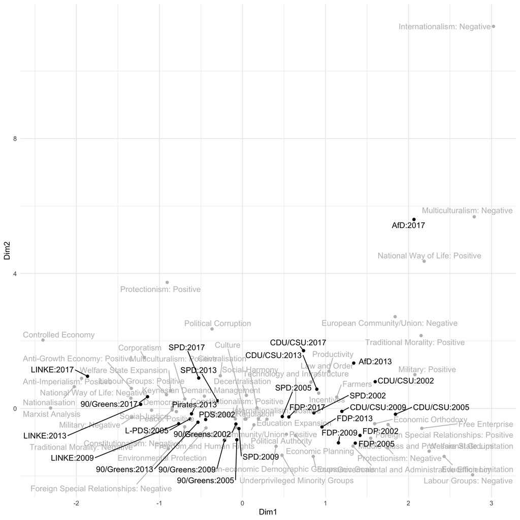

```r
ggplot(plotdata, aes(Dim1, Dim2, color = parameter, label = label)) +
  geom_point() +
  geom_text_repel() +
  scale_colour_manual(values = list(beta="grey", theta = "black"),
                      guide = FALSE)
```

Oof. That’s quite busy.

Let’s try only plotting the `rile_left` and `rile_right` categories. We’ll do this by filtering out all the `rile_none` rows of the data and using the same plot code.

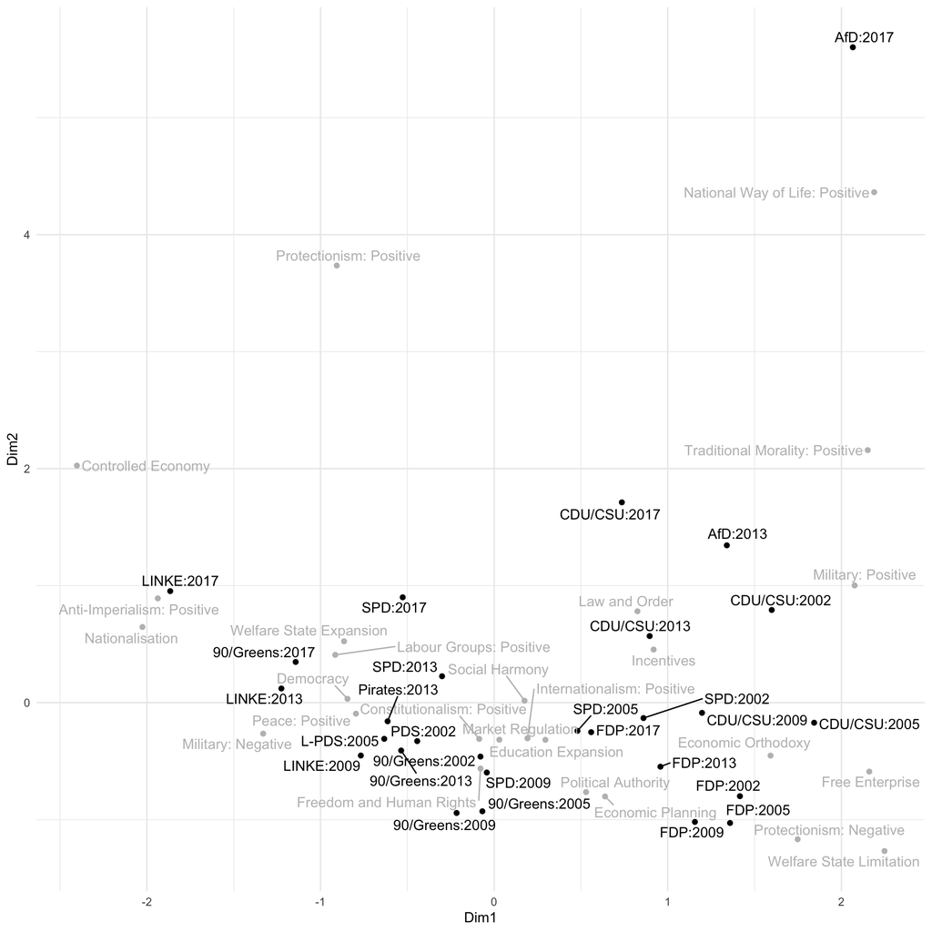

```r
filter(plotdata, !(label %in% rile_none)) %>%
  ggplot(aes(Dim1, Dim2, color = parameter, label = label)) +
  geom_point() +
  geom_text_repel() +
  scale_colour_manual(values = list(beta="grey", theta = "black"),
                      guide = FALSE)
```

## Interpretation

Interpretation time. Consider the SPD manifesto in the 2017 election. According to this scaling model, does it emphasize each of the following themes *more* than other parties, *less* than other parties, or about the *same*?

- Political Authority
- Law and Order
- Constitutionalism
- Controlled Economy

Hint: revisit the final parts of the prerecorded video.

Interpretation:

## Time Series plots

We’ve been collapsing the temporal dimension here. Let’s add those nicely formatted dates we made earlier to the data and see how the parties look over time in terms of the first scaled dimension

```r
ts_plotdata <- data.frame(date = de$edate,
                          party = de$partyabbrev,
                          position = thetas[,1])
```

How about you make the positions over time plot and describe qualitatively what you see

Interpretation:

## Projection

Following the NYT piece, let’s (perhaps unwisely) ask the question, where the two main US parties would be if they emphasized what they really do emphasize in their platforms but were somehow translated into German and found themselves competing in a Federal Election.

For this, we’ll fit the model to the regular German parties and the project the US parties in based on the German `betas`. We can do this conveniently by giving the `ca` function the row numbers of the US parties and asking it to treat these as ‘supplementary’, that is, to define the scaled space without them and then to place them in it.

Most of this code follows the code above, but watch out for the differences

```r
usde <- filter(cmp20, edate > oldest,
               countryname %in% c("Germany", "United States"))
usde_counts <- select(usde, starts_with("per"))

usde_mat <- data.matrix(usde_counts)
rownames(usde_mat) <- usde$label
colnames(usde_mat) <- itemcodes$name

# which indices are to be projected?
extras <- which(usde$countryname == "United States")
extras
```

```
 [1] 29 30 31 32 33 34 35 36 37 38
```

```r
# now fit the model with supplementary rows
mod2 <- ca(usde_mat, suprow = extras)

# and extract the positions
usde_betas <- mod2$colcoord
usde_thetas <- mod2$rowcoord
```

This time you plot it. Note: You *may* find it easier to read if you filter out *all* the betas, not just the `rile_none` ones.

Provide a brief qualitative description of what you see.

Interpretation:

## A more sensible projection?

Assuming the projection question makes sense (it probably does better for some pairs of countries than others, e.g. ones that share an electoral system or some relevant history), now project a *different*, perhaps more reasonable comparison country into the German space and tell us very briefly what you see and whether you think it makes sense.

Interpretation:

## Finally

What do you think is the difference making a space using both countries and making a space with one and projecting another into it? Under what circumstances would these differ?

Interpretation: